# R Notebook

Plot the extracted information

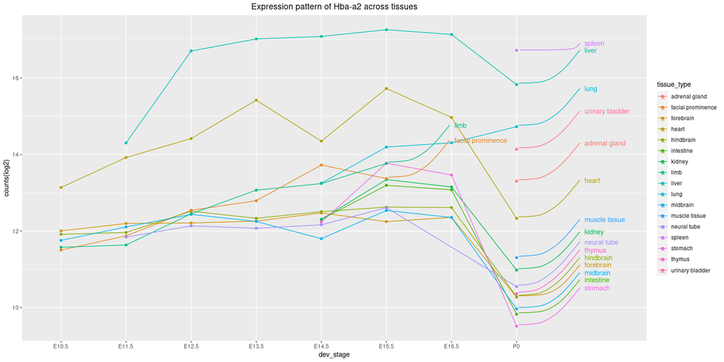

```r
library(ggrepel)
make_label <- function(row){
  if (row['dev_stage'] == max(Hba_frame %>% filter(tissue_type==row['tissue_type']) %>% pull(dev_stage))){
    #print(max(Hba_frame %>% filter(tissue_type==tissue) %>% pull(dev_stage)))\
     return(as.character(row['tissue_type']))
  }else {

    return(NA_character_)
  }
}
Hba_frame[,"label"] <- Hba_frame %>% apply(1,make_label)
# Hba_frame <- Hba_frame %>%
#   mutate(label = if_else(dev_stage == max(Hba_frame %>% filter()), as.character(tissue_type), NA_character_))
ggplot(Hba_frame, aes(x=dev_stage, y=count, group=tissue_type, colour=tissue_type)) + geom_line() + geom_point() + expand_limits(x= c(4, 10)) +
  # geom_text_repel(
  #   aes(label = gsub("^.*$", " ", label)),
  #   # This will force the correct position of the link's right end.

  #   segment.curvature = -0.1,
  #   segment.square = TRUE,
  #   segment.color = 'grey',
  #   box.padding = 0.1,
  #   point.padding = 0.6,
  #   nudge_x = 1,
  #   nudge_y = 1,
  #   force = 15,
  #   hjust = 0,
  #   direction = "y",
  #   na.rm = TRUE,
  #   xlim = c(5, 10),
  #   ylim = c(0, 150000),
  # ) +
  geom_text_repel(data = . %>% filter(!is.na(label)),
                  aes(label = paste0("  ", label)),
                  #segment.alpha = 0, ## This will 'hide' the link
                  segment.curvature = -0.1,
                  segment.square = TRUE,
                  # segment.color = 'grey',
                  box.padding = 0.1,
                  point.padding = 0.6,
                  nudge_x = 1,
                  nudge_y = 1,
                 force = 0.5,
                  hjust = 0,
                  direction="y",
                  na.rm = TRUE,
                  xlim = c(5, 10),
                  ylim = c(10,17),
)                   +
  ylab("counts(log2)") + ggtitle("Expression pattern of Hba-a2 across tissues") + theme(plot.title = element_text(hjust = 0.5))
```

Top 5 Universally highly expressed protein across all tissues regardless of stages (by percentage in tissues)

```r
##Collapse dev_stages
collapsed_matrices <- matrix(data=NA, nrow = nrow(all_counts), ncol = length(tissue_types))
rownames(collapsed_matrices) <- rownames(all_counts)
walker <- 1
for (tissue in tissue_types){
  tissue_subset_ids <- meta %>% filter(tissue_type == tissue) %>% pull(id)
  all_avgs <- apply(all_counts[,tissue_subset_ids],1, mean)
  percent_counts <- all_avgs/sum(all_avgs)
  collapsed_matrices[,walker] <- percent_counts
  walker <- walker + 1
}
all_sums <- apply(collapsed_matrices,1, sum)
for (i in 1:10){
  print(paste0("The highests expressed protein acrossed all tissue in order ",i ,": ", names(sort(all_sums,decreasing=TRUE))[i]))
}
```

```
[1] "The highests expressed protein acrossed all tissue in order 1: Hba-a2"
[1] "The highests expressed protein acrossed all tissue in order 2: Hbb-bs"
[1] "The highests expressed protein acrossed all tissue in order 3: mt-Atp6"
[1] "The highests expressed protein acrossed all tissue in order 4: Hba-a1"
[1] "The highests expressed protein acrossed all tissue in order 5: mt-Atp8"
[1] "The highests expressed protein acrossed all tissue in order 6: Hbb-bt"
[1] "The highests expressed protein acrossed all tissue in order 7: Actb"
[1] "The highests expressed protein acrossed all tissue in order 8: Ftl1"
[1] "The highests expressed protein acrossed all tissue in order 9: Ppia"
[1] "The highests expressed protein acrossed all tissue in order 10: Acta1"
```

Top 5 Universally highly expressed protein across all tissues regardless of stages (by ranking)

```r
##Collapse dev_stages
collapsed_matrices <- matrix(data=NA, nrow = nrow(all_counts), ncol = length(tissue_types))
rownames(collapsed_matrices) <- rownames(all_counts)
walker <- 1
for (tissue in tissue_types){
  tissue_subset_ids <- meta %>% filter(tissue_type == tissue) %>% pull(id)
  all_avgs <- apply(all_counts[,tissue_subset_ids],1, mean)
  all_ranking <- rank(all_avgs)
  collapsed_matrices[,walker] <- all_ranking
  walker <- walker + 1
}
all_sums <- apply(collapsed_matrices,1, sum)
for (i in 1:10){
  print(paste0("The highests expressed protein acrossed all tissue in order ",i ,": ", names(sort(all_sums, decreasing = TRUE))[i]))
}
```

```
[1] "The highests expressed protein acrossed all tissue in order 1: mt-Atp6"
[1] "The highests expressed protein acrossed all tissue in order 2: mt-Atp8"
[1] "The highests expressed protein acrossed all tissue in order 3: Hba-a2"
[1] "The highests expressed protein acrossed all tissue in order 4: Actb"
[1] "The highests expressed protein acrossed all tissue in order 5: Ppia"
[1] "The highests expressed protein acrossed all tissue in order 6: Ftl1"
[1] "The highests expressed protein acrossed all tissue in order 7: mt-Nd1"
[1] "The highests expressed protein acrossed all tissue in order 8: Eef1a1"
[1] "The highests expressed protein acrossed all tissue in order 9: mt-Cytb"
[1] "The highests expressed protein acrossed all tissue in order 10: mt-Co1"
```

expression distribution acrossed different tissues (box plot)

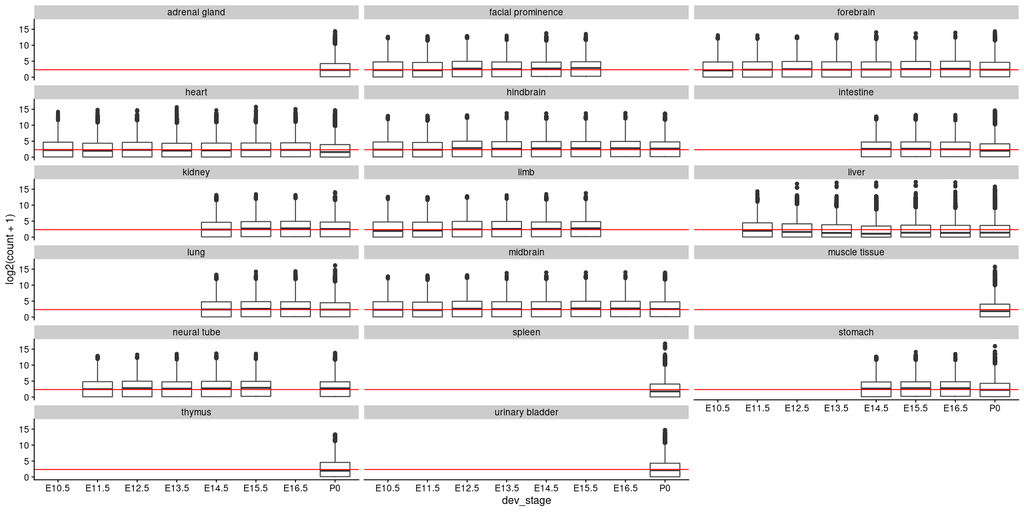

```r
library(cowplot)
all_counts_melted <- data.frame(all_counts) %>% gather("id", "count")
all_counts_melted <- all_counts_melted %>% inner_join((meta %>% select(id, tissue_type, dev_stage)), by="id")
  ggplot(data=all_counts_melted, aes(x=dev_stage, y=log2(count+1))) + geom_boxplot() +  facet_wrap(~ tissue_type, ncol=3) + theme_cowplot(12) + geom_hline(yintercept=median(log2(all_counts+1)), colour="red")
```

expression distribution acrossed different tissues (histogram)

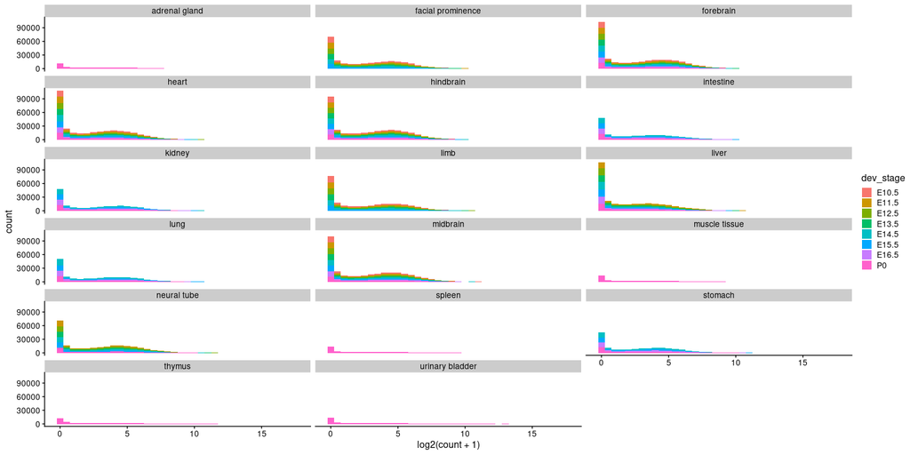

```r
all_counts_melted <- data.frame(all_counts) %>% gather("id", "count")
all_counts_melted <- all_counts_melted %>% inner_join((meta %>% select(id, tissue_type, dev_stage)), by="id")
  suppressWarnings(ggplot(data=all_counts_melted, aes(x=log2(count+1), fill=dev_stage)) + geom_histogram(binwidth = 0.5) +  facet_wrap(~ tissue_type, ncol=3) + theme_cowplot(12))
```

expression distribution acrossed different tissues (histogram log transformed)

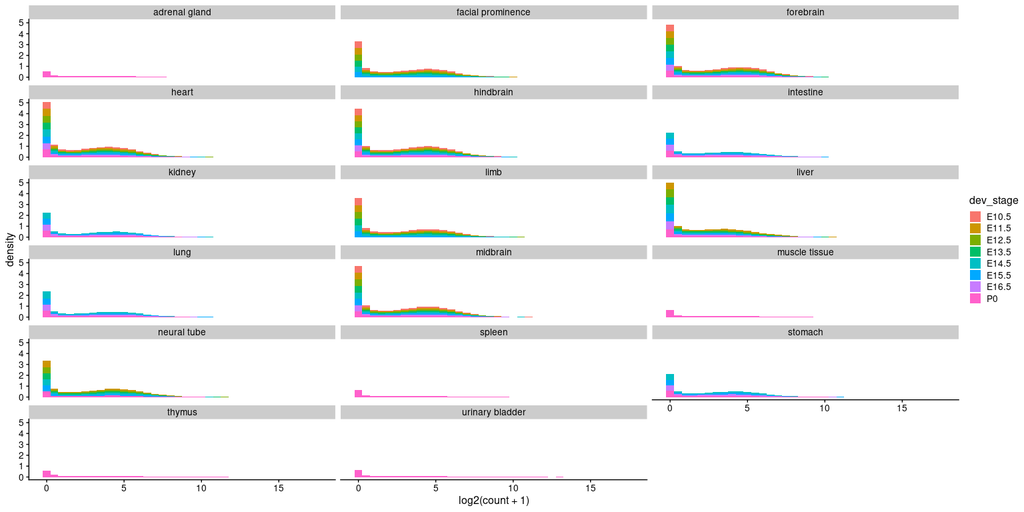

```r
all_counts_melted <- data.frame(all_counts) %>% gather("id", "count")
all_counts_melted <- all_counts_melted %>% inner_join((meta %>% select(id, tissue_type, dev_stage)), by="id")
  suppressWarnings(ggplot(data=all_counts_melted, aes(x=log2(count+1), y=..density.. ,fill=dev_stage)) + geom_histogram(binwidth = 0.5) +  facet_wrap(~ tissue_type, ncol=3) + theme_cowplot(12))
```

expression distribution acrossed different tissues (box plot collapsed dev_stages)

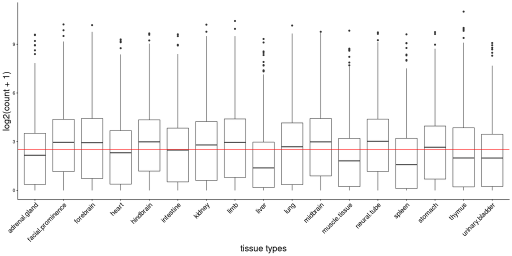

expression distribution acrossed different tissues (box plot collapsed dev_stages not limited to pc genes)

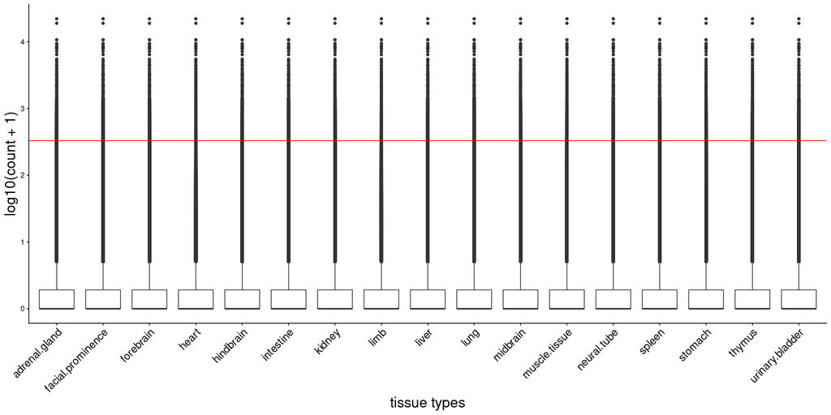

expression distribution acrossed different tissues (histogram collapsed by dev_stage)

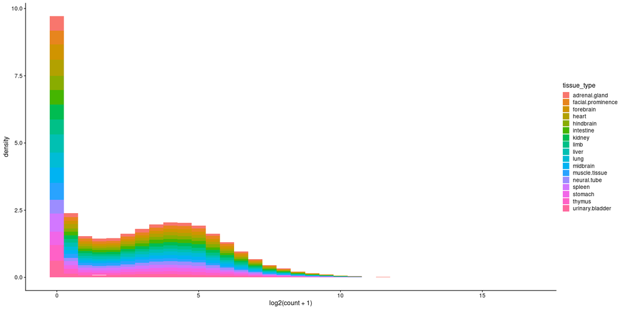

```r
  suppressWarnings(ggplot(data=melted_collapsed_dev, aes(x=log2(count+1), fill=tissue_type, y=..density..)) + geom_histogram(binwidth = 0.5) + theme_cowplot(12))
```

expression distribution acrossed different tissues (freq_plot collapsed by dev_stage)

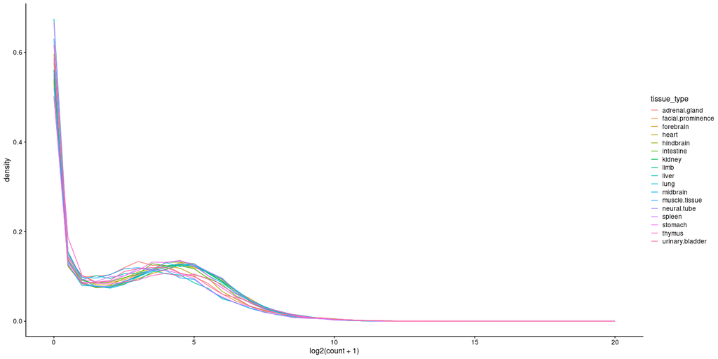

```r
  ggplot(data=melted_collapsed_dev, aes(x=log2(count+1), y=..density.., colour=tissue_type)) + geom_freqpoly(binwidth=0.5) + theme_cowplot(12) + scale_x_continuous(limits=c(0, 20))
```

Mean-variance

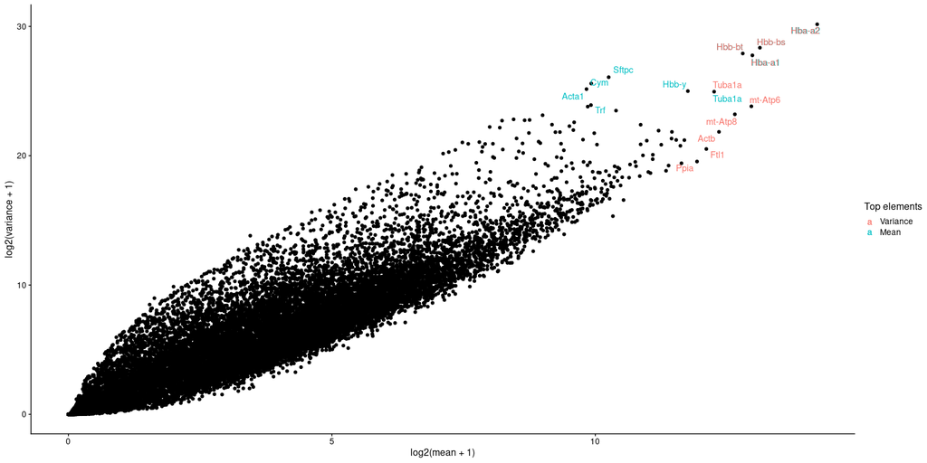

```r
library(ggrepel)
all_counts_mean_var <- all_counts
all_counts_mean_var <- cbind(all_counts_mean_var, mean=apply(all_counts,1,mean))
all_counts_mean_var <- cbind(all_counts_mean_var, variance=apply(all_counts,1,var))
ggplot(data=data.frame(all_counts_mean_var), aes(x=log2(mean+1), y=log2(variance+1))) + geom_point() + theme_cowplot(12) +
  geom_text_repel(data=data.frame(all_counts_mean_var) %>% rownames_to_column(var="rowname") %>% slice_max(variance, n=10), aes(x=log2(mean+1), y=log2(variance), label=rowname, colour="red")) +
  geom_text_repel(data=data.frame(all_counts_mean_var) %>% rownames_to_column(var="rowname") %>% slice_max(mean, n=10), aes(x=log2(mean+1), y=log2(variance), label=rowname, colour="blue")) + scale_colour_discrete(name = "Top elements", labels = c("Variance", "Mean"))
```

Mean and variance all together but hue by organism type

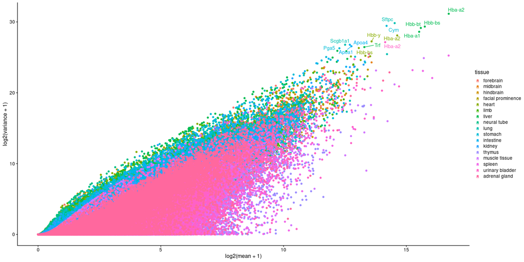

```r
collapsed_matrices <- data.frame(mean=double(), variance=double(), tissue=character(), row=character())
colnames(collapsed_matrices) <- c("mean", "variance", "tissue")
for (tissue in tissue_types){
  tissue_subset_ids <- meta %>% filter(tissue_type == tissue) %>% pull(id)
  all_means <- apply(all_counts[,tissue_subset_ids],1, mean)
  all_variance <- apply(all_counts[,tissue_subset_ids],1, var)
  temp_matrix <- data.frame(mean=all_means, variance=all_variance, tissue) %>% rownames_to_column("rowname")
  collapsed_matrices <- rbind(collapsed_matrices, temp_matrix)
}
ggplot(data=collapsed_matrices, aes(x=log2(mean+1), y=log2(variance+1), colour=tissue)) + geom_point()+ theme_cowplot(12) +
  geom_text_repel(data=collapsed_matrices %>% slice_max(variance+mean, n=15), aes(x=log2(mean+1), y=log2(variance+1), label=rowname, colour=tissue))
```

```r
  #geom_text_repel(data=collapsed_matrices %>% rownames_to_column("row") %>% slice_max(mean, n=10), aes(x=log2(mean+1), y=log2(variance+1), label=row, colour=tissue))

  #scale_colour_discrete(name = "Top elements", labels = c("Variance", "Mean"))
```

Variability across tissue types

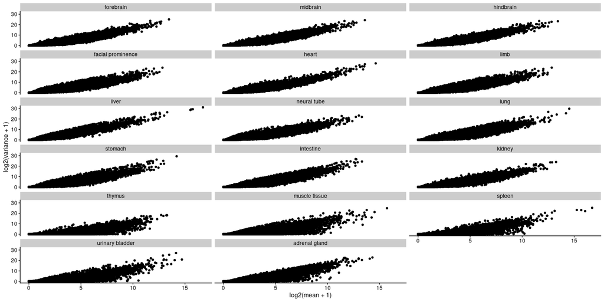

```r
ggplot(data=collapsed_matrices, aes(x=log2(mean+1), y=log2(variance+1))) + geom_point() +  facet_wrap(~ tissue, ncol=3) + theme_cowplot(12)
```

Zooming in on highly epxressed gene (>1025)

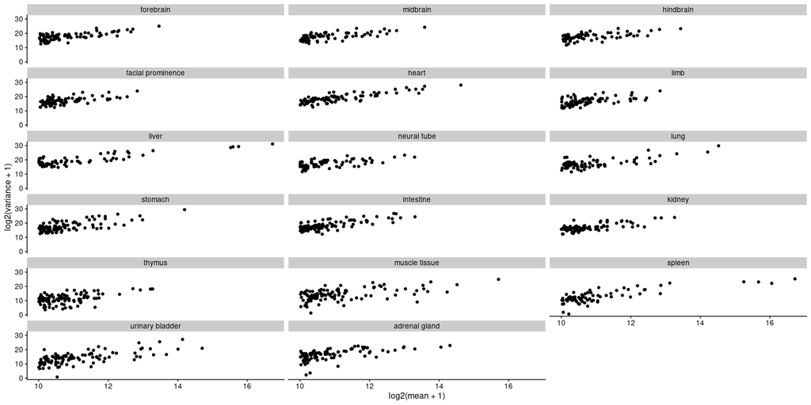

```r
ggplot(data=collapsed_matrices  %>% filter(log2(mean+1) >=10), aes(x=log2(mean+1), y=log2(variance+1))) + geom_point() +  facet_wrap(~ tissue, ncol=3) + theme_cowplot(12)
```

Distribution of the TFs

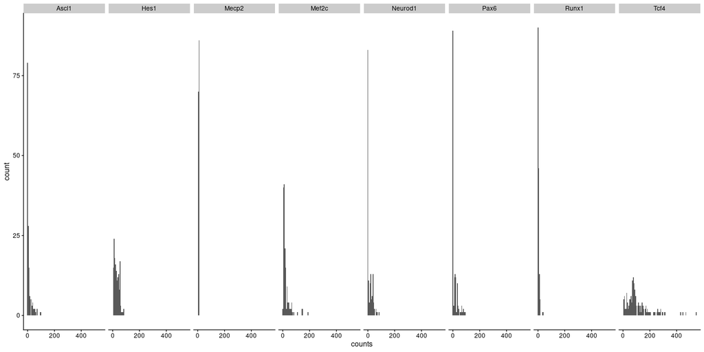

```r
TFCounts <- data.frame(all_counts[TFs,])
TFCounts <- TFCounts %>% rownames_to_column("rowname")
TFCounts <- TFCounts %>% gather("id", "counts", -rowname)
TFCounts <- TFCounts %>% left_join((meta %>% select(tissue_type, dev_stage, id)), by="id")

ggplot(data=TFCounts, aes(x=counts)) + geom_histogram(bins = 100) + facet_grid(~  rowname) + theme_cowplot(12)
```

Distribution of the TFs (Log transformed)

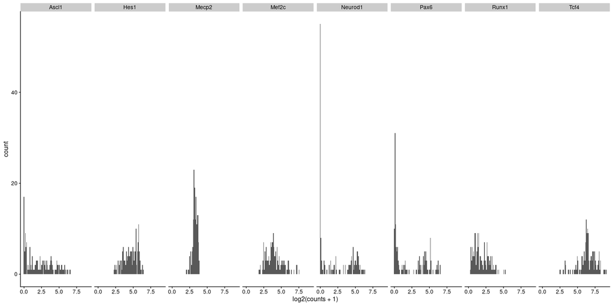

```r
TFCounts <- data.frame(all_counts[TFs,])
TFCounts <- TFCounts %>% rownames_to_column("rowname")
TFCounts <- TFCounts %>% gather("id", "counts", -rowname)
TFCounts <- TFCounts %>% left_join((meta %>% select(tissue_type, dev_stage, id)), by="id")

ggplot(data=TFCounts, aes(x=log2(counts+1))) + geom_histogram(bins = 100) + facet_grid(~  rowname) + theme_cowplot(12)
```

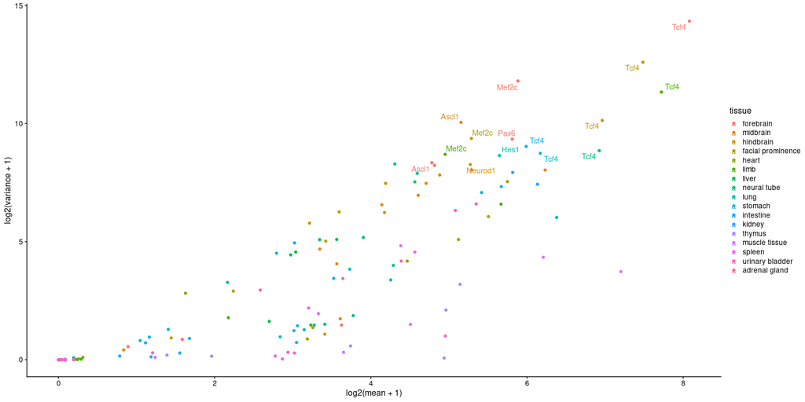

```r
TFCounts <- data.frame(all_counts[TFs,])
TFCounts <- TFCounts %>% rownames_to_column("rowname")
TFCounts <- TFCounts %>% gather("id", "counts", -rowname)
TFCounts <- TFCounts %>% left_join((meta %>% select(tissue_type, dev_stage, id)), by="id")

ggplot(data=collapsed_matrices %>% filter(rowname %in% TFs), aes(x=log2(mean+1), y=log2(variance+1), colour=tissue)) + geom_point()+ theme_cowplot(12) +
  geom_text_repel(data=collapsed_matrices %>% filter(rowname %in% TFs) %>% slice_max(variance+mean, n=15), aes(x=log2(mean+1), y=log2(variance+1), label=rowname, colour=tissue))
```

Box plots for TFs across tissues

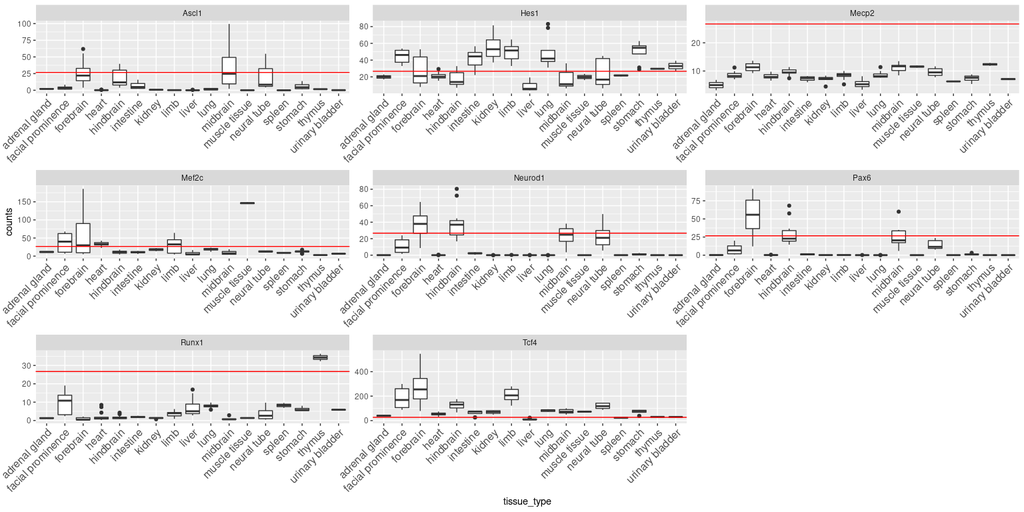

```r
Tcf4Counts <- TFCounts %>% filter(rowname=="Tcf4")

ggplot(data=TFCounts, aes(y=counts, x=tissue_type)) + geom_boxplot() + theme(axis.text.x = element_text(size = 12, angle = 45, hjust = 1)) + facet_wrap(~ rowname, scales = "free") + geom_hline(yintercept=mean(TFCounts$counts), colour="red")
```

Expression across dev_stage and tissues

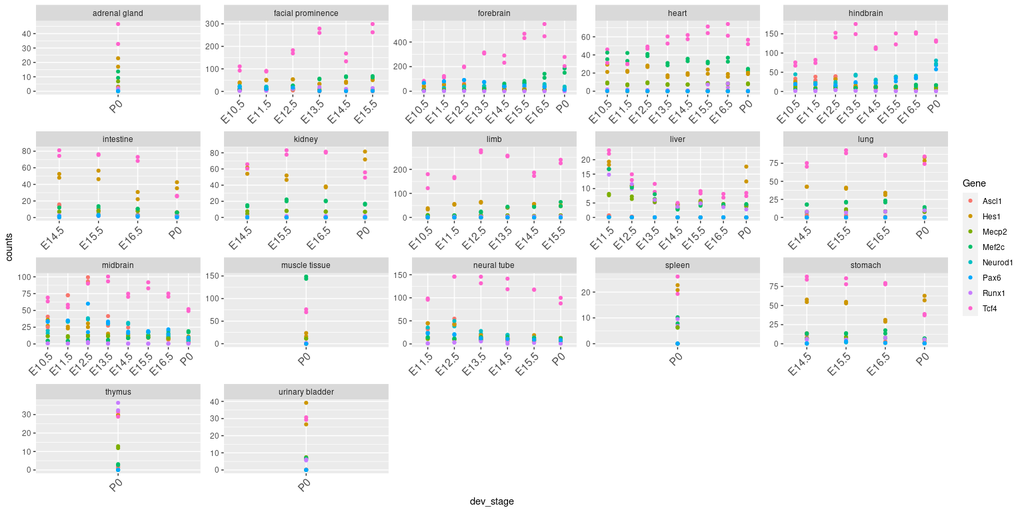

```r
ggplot(data=TFCounts, aes(x=dev_stage, y=counts, colour=rowname)) + geom_point() + theme(axis.text.x = element_text(size = 12, angle = 45, hjust = 1)) + facet_wrap(~ tissue_type, scales = "free") + scale_colour_discrete(name = "Gene")
```

Expression across dev_stage and tissues (log transformed)

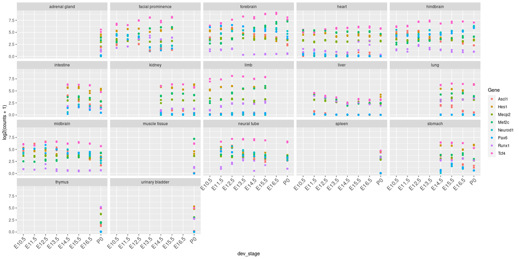

```r
ggplot(data=TFCounts, aes(x=dev_stage, y=log2(counts+1), colour=rowname)) + geom_point() + theme(axis.text.x = element_text(size = 12, angle = 45, hjust = 1)) + facet_wrap(~ tissue_type) + scale_colour_discrete(name = "Gene")
```

histograms of expresssion distribution by tissues

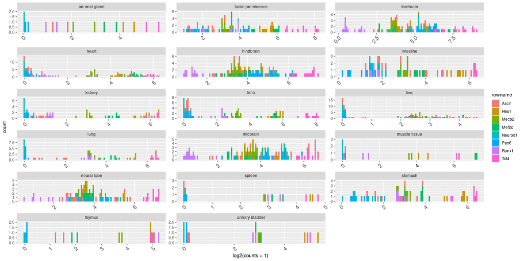

```r
ggplot(data=TFCounts, aes(x=log2(counts+1), fill=rowname)) + geom_histogram(bins=100) + theme(axis.text.x = element_text(size = 12, angle = 45, hjust = 1)) + facet_wrap(~ tissue_type, ncol=3,scales = "free") + scale_colour_discrete(name = "Gene")
```

cluster correlation heatmap

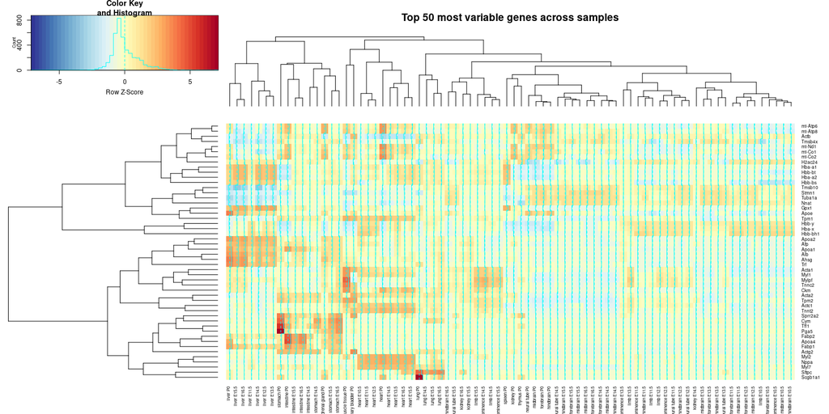

```r
library(gplots)
library(RColorBrewer)
# Get some nicer colours
mypalette <- brewer.pal(11, "RdYlBu")
# http://colorbrewer2.org/#type=sequential&scheme=BuGn&n=3
morecols <- colorRampPalette(mypalette)
# Set up colour vector for celltype variable
col.cell <- (c("purple","orange")[meta$tissue_type])[1:(length(meta$tissue_type)/2)]
# Plot the
avg_counts_tissue_name <- avg_counts
colnames(avg_counts_tissue_name) <- sapply(colnames(avg_counts), function(x){temp_row <- meta %>% filter(id==x)
                                                                             return(paste0(temp_row %>% pull(tissue_type), " ",temp_row %>% pull(dev_stage)))})
heatmap.2(log2(avg_counts_tissue_name+1)[(order(apply(avg_counts,1,var), decreasing = TRUE))[1:50],],
          col=rev(morecols(50)),
          trace="column",
          main="Top 50 most variable genes across samples",
          ColSideColors=col.cell,
          scale = "row")
```

cluster correlation heatmap (only TFs)

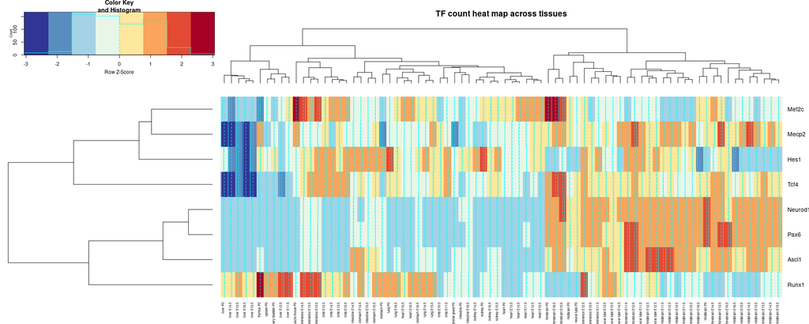

```r
library(gplots)
library(RColorBrewer)
# Get some nicer colours
mypalette <- brewer.pal(11, "RdYlBu")
# http://colorbrewer2.org/#type=sequential&scheme=BuGn&n=3
morecols <- colorRampPalette(mypalette)
# Set up colour vector for celltype variable
col.cell <- (c("purple","orange")[meta$tissue_type])[1:(length(meta$tissue_type)/2)]
# Plot the heatmap
avg_counts_tissue_name <- avg_counts
colnames(avg_counts_tissue_name) <- sapply(colnames(avg_counts), function(x){temp_row <- meta %>% filter(id==x)
                                                                             return(paste0(temp_row %>% pull(tissue_type), " ",temp_row %>% pull(dev_stage)))})
heatmap.2(log2(avg_counts_tissue_name+1)[TFs,],
          col=rev(morecols(length(TFs))),
          trace="column",
          main="TF count heat map across tissues",
          ColSideColors=col.cell,
          scale="row")
```

Midbrain cluster correlation heatmap (only TFs)

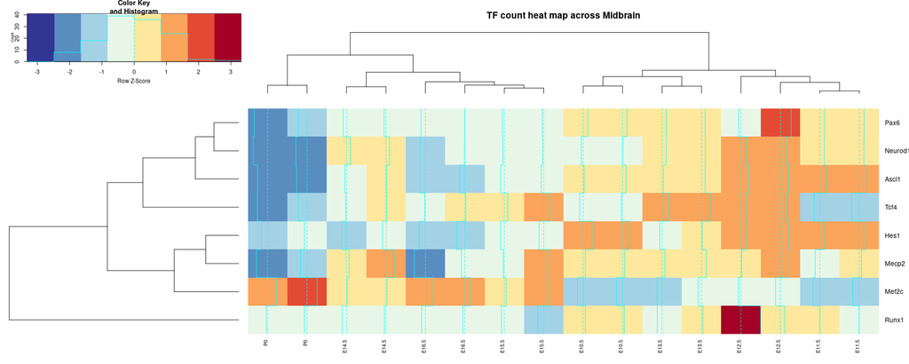

```r
# Set up colour vector for celltype variable
col.cell <- (c("purple","orange")[meta$tissue_type])[1:(length(meta %>% filter(tissue_type=="midbrain") %>% pull(id)))]
# Plot the heatmap
midbrain_id <- meta %>% filter(tissue_type == "midbrain") %>% pull(id)
midbrain_counts <- all_counts[,midbrain_id]
colnames(midbrain_counts) <- sapply(colnames(midbrain_counts), function(x){temp_row <- meta %>% filter(id==x)
                                                                             return(paste0(temp_row %>% pull(dev_stage)))})
heatmap.2(log2(midbrain_counts+1)[TFs,],
          col=rev(morecols(length(TFs))),
          trace="column",
          main="TF count heat map across Midbrain",
          ColSideColors=col.cell,
          scale="row")
```

Hindbrain cluster correlation heatmap (only TFs)

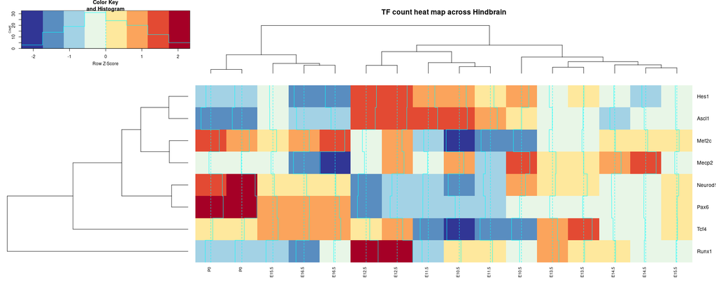

```r
# Set up colour vector for celltype variable
col.cell <- (c("purple","orange")[meta$tissue_type])[1:(length(meta %>% filter(tissue_type=="hindbrain") %>% pull(id)))]
# Plot the heatmap
hindbrain_id <- meta %>% filter(tissue_type == "hindbrain") %>% pull(id)
hindbrain_counts <- all_counts[,hindbrain_id]
colnames(hindbrain_counts) <- sapply(colnames(hindbrain_counts), function(x){temp_row <- meta %>% filter(id==x)
                                                                             return(paste0(temp_row %>% pull(dev_stage)))})
heatmap.2(log2(hindbrain_counts+1)[TFs,],
          col=rev(morecols(length(TFs))),
          trace="column",
          main="TF count heat map across Hindbrain",
          ColSideColors=col.cell,
          scale="row")
```

variability (across tissues, within tissues as well) mean-variance is the ranking similar across tissues

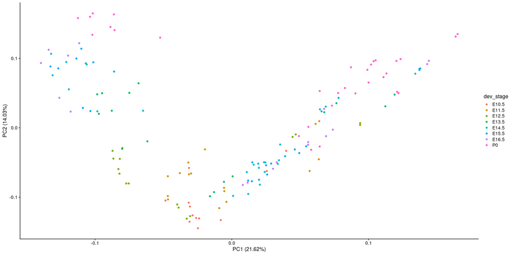

```r
##Remove zero variance
all_counts_drop_var <- (t(all_counts))[, which(apply(t(all_counts),2,var) !=0)]
all_counts.pca <- prcomp(all_counts_drop_var, center = TRUE,scale. = TRUE)
library(ggfortify)
autoplot(all_counts.pca, data=meta, colour="dev_stage") + theme_cowplot(12)
```

variability (across tissues, within tissues as well) mean-variance is the ranking similar across tissues

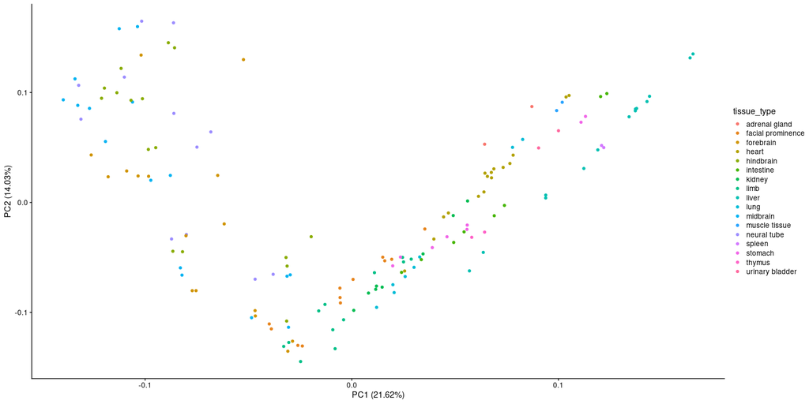